# Data Science Interview Project

## Random Forest Full Model (No-resample)

### Random Forest Model

```r
randomforest.data <- training.train %>% select(-outpatient, -inpatient, -professional)

rf <- randomForest(SURGERY ~ ., data = randomforest.data,  mtry = 4, ntree = 250, importance = TRUE) ## 4 Levels to decision trees, 1000 trees for each prediction, keep the importance metrics for variables

rf
```

```
##
## Call:
##  randomForest(formula = SURGERY ~ ., data = randomforest.data,      mtry = 4, ntree = 250, importance = TRUE)
##                Type of random forest: classification
##                      Number of trees: 250
## No. of variables tried at each split: 4
##
##         OOB estimate of  error rate: 1.24%
## Confusion matrix:
##        No Yes class.error
## No  30709 100 0.003245805
## Yes   289 375 0.435240964
```

#### Importance of Variables

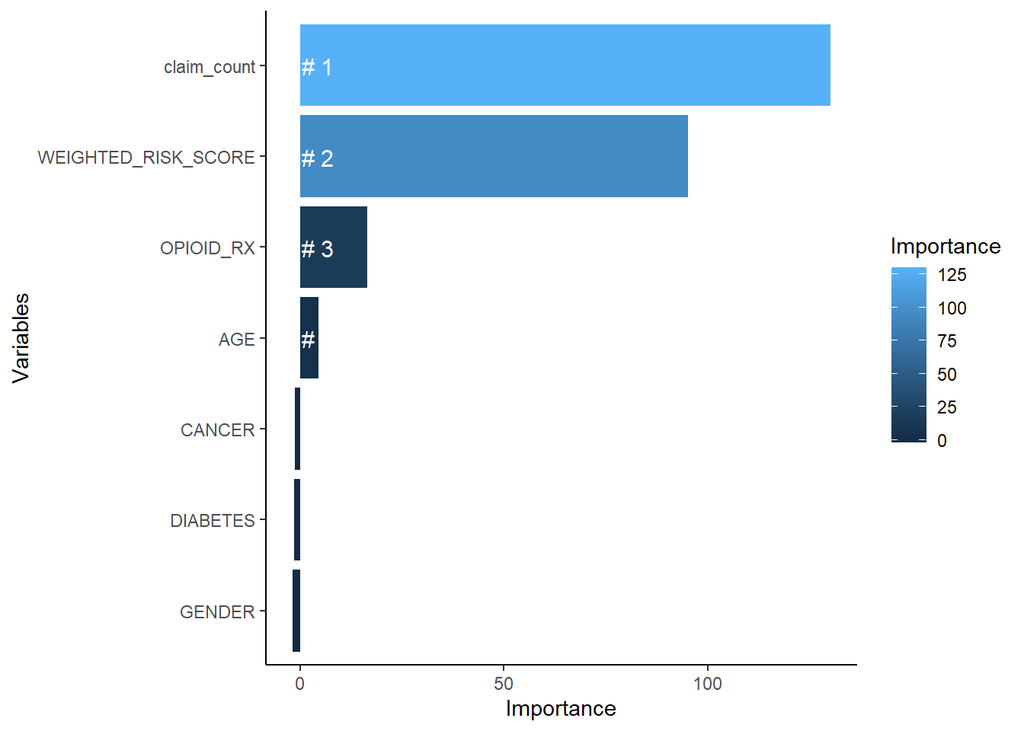

```r
importance = importance(rf)
varImportance = data.frame(Variables = row.names(importance),
                           Importance = round(importance[, "MeanDecreaseAccuracy"], 2))

rankImportance = varImportance %>% mutate(Rank = paste('#', dense_rank(desc(Importance))))

ggplot(rankImportance, aes(x = reorder(Variables,Importance), y= Importance, fill = Importance))  +
  geom_bar(stat='identity') +
  geom_text(aes(x = Variables, y = 0.5, label = Rank),
            hjust=0, vjust=0.55, size = 4, colour = 'white') +
  labs(x = 'Variables') +
  coord_flip() +
  theme_classic()
```

#### Validation of Full Model

```r
randomforest.test <- training.test %>% filter(is.na(outpatient))
retain_p <- rf %>% predict(newdata = training.test)

table(
  actualclass = training.test$SURGERY,
  predictedclass = retain_p
) %>%
  confusionMatrix(positive='Yes') %>%
  print()
```

```
## Confusion Matrix and Statistics
##
##            predictedclass
## actualclass    No   Yes
##         No  10236    36
##         Yes    96   124
##
##                Accuracy : 0.9874
##                  95% CI : (0.9851, 0.9895)
##     No Information Rate : 0.9848
##     P-Value [Acc > NIR] : 0.01241
##
##                   Kappa : 0.6464
##
##  Mcnemar's Test P-Value : 2.817e-07
##
##             Sensitivity : 0.77500
##             Specificity : 0.99071
##          Pos Pred Value : 0.56364
##          Neg Pred Value : 0.99650
##              Prevalence : 0.01525
##          Detection Rate : 0.01182
##    Detection Prevalence : 0.02097
##       Balanced Accuracy : 0.88285
##
##        'Positive' Class : Yes
##
```

### Reduced Random Forest Model

```r
randomforest.data.2 <- randomforest.data %>% select(-CANCER, -GENDER, - DIABETES)
rf2 <- randomForest(SURGERY ~ ., data = randomforest.data.2,  mtry = 4, ntree = 250, importance = TRUE) ## 4 Levels to decision trees, 1000 trees for each prediction, keep the importance metrics for variables

rf2
```

```
##
## Call:
##  randomForest(formula = SURGERY ~ ., data = randomforest.data.2,      mtry = 4, ntree = 250, importance = TRUE)
##                Type of random forest: classification
##                      Number of trees: 250
## No. of variables tried at each split: 4
##
##         OOB estimate of  error rate: 1.35%
## Confusion matrix:
##        No Yes class.error
## No  30690 119 0.003862508
## Yes   305 359 0.459337349
```

#### Importance of Variables

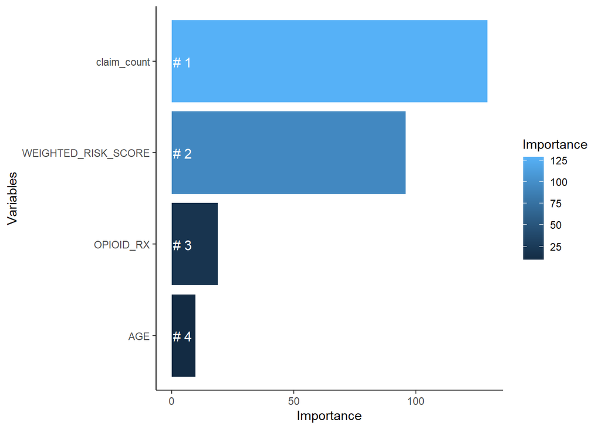

```r
importance = importance(rf2)
varImportance = data.frame(Variables = row.names(importance),
                           Importance = round(importance[, "MeanDecreaseAccuracy"], 2))

rankImportance = varImportance %>% mutate(Rank = paste('#', dense_rank(desc(Importance))))

ggplot(rankImportance, aes(x = reorder(Variables,Importance), y= Importance, fill = Importance))  +
  geom_bar(stat='identity') +
  geom_text(aes(x = Variables, y = 0.5, label = Rank),
            hjust=0, vjust=0.55, size = 4, colour = 'white') +
  labs(x = 'Variables') +
  coord_flip() +
  theme_classic()
```

#### Validation of Reduced Model

```r
randomforest.test <- training.test %>% filter(is.na(outpatient))
retain_p <- rf2 %>% predict(newdata = training.test)

table(
  actualclass = training.test$SURGERY,
  predictedclass = retain_p
) %>%
  confusionMatrix(positive='Yes') %>%
  print()
```

```
## Confusion Matrix and Statistics
##
##            predictedclass
## actualclass    No   Yes
##         No  10223    49
##         Yes    92   128
##
##                Accuracy : 0.9866
##                  95% CI : (0.9842, 0.9887)
##     No Information Rate : 0.9831
##     P-Value [Acc > NIR] : 0.0027581
##
##                   Kappa : 0.6381
##
##  Mcnemar's Test P-Value : 0.0004046
##
##             Sensitivity : 0.72316
##             Specificity : 0.99108
##          Pos Pred Value : 0.58182
##          Neg Pred Value : 0.99523
##              Prevalence : 0.01687
##          Detection Rate : 0.01220
##    Detection Prevalence : 0.02097
##       Balanced Accuracy : 0.85712
##
##        'Positive' Class : Yes
##
```

## Random Forest Data Resampling (Over-Sampling)

```r
### Resampling the Data to get rid of the imbalanced outcome
randomforest.data.resample <- ovun.sample(SURGERY ~ ., data = randomforest.data, method = "over", N = 50000, seed = 1234)$data

freq(randomforest.data.resample$SURGERY)
```

```
## Frequencies
## randomforest.data.resample$SURGERY
## Type: Factor
##
##                Freq   % Valid   % Valid Cum.   % Total   % Total Cum.
## ----------- ------- --------- -------------- --------- --------------
##          No   30809     61.62          61.62     61.62          61.62
##         Yes   19191     38.38         100.00     38.38         100.00
##        <NA>       0                               0.00         100.00
##       Total   50000    100.00         100.00    100.00         100.00
```

### Resampled Random Forest Full Model

```r
### Random Forest Model
rf3 <- randomForest(SURGERY ~ ., data = randomforest.data.resample,  mtry = 5, ntree = 250, importance = TRUE) ## 4 Levels to decision trees, 1000 trees for each prediction, keep the importance metrics for variables

rf3
```

```
##
## Call:
##  randomForest(formula = SURGERY ~ ., data = randomforest.data.resample,      mtry = 5, ntree = 250, importance = TRUE)
##                Type of random forest: classification
##                      Number of trees: 250
## No. of variables tried at each split: 5
##
##         OOB estimate of  error rate: 0.36%
## Confusion matrix:
##        No   Yes class.error
## No  30628   181 0.005874907
## Yes     0 19191 0.000000000
```

#### Variable Importance

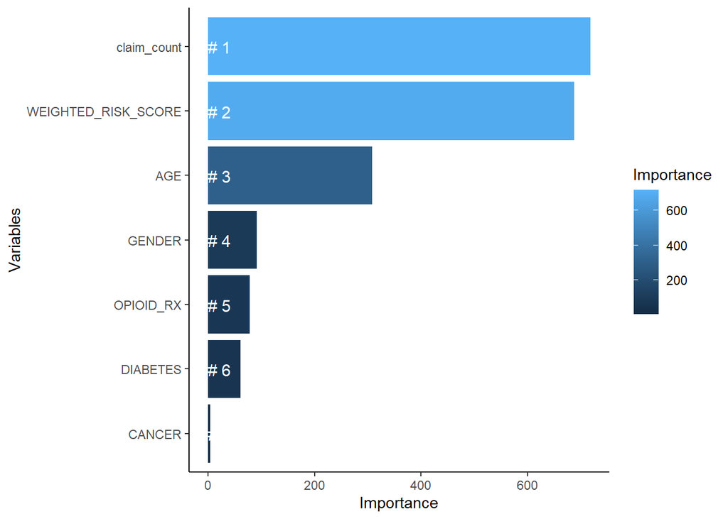

```r
importance = importance(rf3)
varImportance = data.frame(Variables = row.names(importance),
                           Importance = round(importance[, "MeanDecreaseAccuracy"], 2))

rankImportance = varImportance %>% mutate(Rank = paste('#', dense_rank(desc(Importance))))

ggplot(rankImportance, aes(x = reorder(Variables,Importance), y= Importance, fill = Importance))  +
  geom_bar(stat='identity') +
  geom_text(aes(x = Variables, y = 0.5, label = Rank),
            hjust=0, vjust=0.55, size = 4, colour = 'white') +
  labs(x = 'Variables') +
  coord_flip() +
  theme_classic()
```

#### Validation of Full Model

```r
retain_p <- rf3 %>% predict(newdata = training.test)

table(
  actualclass = training.test$SURGERY,
  predictedclass = retain_p
) %>%
  confusionMatrix(positive='Yes') %>%
  print()
```

```
## Confusion Matrix and Statistics
##
##            predictedclass
## actualclass    No   Yes
##         No  10204    68
##         Yes    86   134
##
##                Accuracy : 0.9853
##                  95% CI : (0.9828, 0.9875)
##     No Information Rate : 0.9807
##     P-Value [Acc > NIR] : 0.0002264
##
##                   Kappa : 0.6276
##
##  Mcnemar's Test P-Value : 0.1707184
##
##             Sensitivity : 0.66337
##             Specificity : 0.99164
##          Pos Pred Value : 0.60909
##          Neg Pred Value : 0.99338
##              Prevalence : 0.01925
##          Detection Rate : 0.01277
##    Detection Prevalence : 0.02097
##       Balanced Accuracy : 0.82750
##
##        'Positive' Class : Yes
##
```

### Model choice for official predictions: Reduced Random Forest Model

```r
model.testing <- rf2 %>% predict(newdata = testing.data, "prob")

predictions <- data.frame(MEMBER_ID = testing.data$MEMBER_ID, Prediction = model.testing[,2])

write.csv(predictions, file = "C:\\Users\\jorda\\OneDrive\\Desktop\\predictions.csv")
### Threshold will be 0.408, because the top 2% of the predictions ends at that probability. 2% of Training data had surgery so we want to reflect that.
```

## Final Product

#### Threshold: 0.408

I have chosen to use the threshold 0.408 for my prediction probability classification. The reason for this being that is the threshold that reflects the top 2% of the predictions, which was the same as the percentage of surgeries within the training sample. The thought behind this is if we are predicting surgeries 2% of the testing data should be classified as surgeries.

#### What surgery are we predicting?

#### Top 50 ICD-10 Procedure Codes for Surgery Claims in the Dataset

```r
train_desc_surg <- training.data %>% filter(SURGERY == "Yes")                ### Limit the data to only individuals that underwent surgery
ICD10.codes <- freq(train_desc_surg$ICD10, order = "freq") %>% tb()          ### Get the counts of the individual ICD-10 codes
top50.codes <- ICD10.codes[1:50,1:2]                                         ### Keep the top 50 codes and the frequencies associated

### Manually insert the ICD-10 Code Descriptions
top50 <- top50.codes %>% mutate(CODE_DESCRIPTION = case_when(ICD10 == "M79651" ~ "Pain in right thigh",
                                                             ICD10 == "M25529" ~ "Pain in unspecified elbow",
                                                             ICD10 == "M79674" ~ "Pain in right toe(s)",
                                                             ICD10 == "M79642" ~ "Pain in left hand",
                                                             ICD10 == "M25551" ~ "Pain in right hip",
                                                             ICD10 == "M25562" ~ "pain experienced in the left knee",
                                                             ICD10 == "M7910" ~ "Fistula, unspecified joint",
                                                             ICD10 == "M25659" ~ "Stiffness of unspecified hip, not elsewhere classified",
                                                             ICD10 == "M79644" ~ "Pain in right finger(s)",
                                                             ICD10 == "M25641" ~ "Stiffness of right hand, not elsewhere classified",
                                                             ICD10 == "M25652" ~ "Stiffness of left hip, not elsewhere classified",
                                                             ICD10 == "M62830" ~ "back muscle spasms",
                                                             ICD10 == "M25561" ~ "pain in the right knee",
                                                             ICD10 == "M25651" ~ "Stiffness of right hip, not elsewhere classified",
                                                             ICD10 == "M79652" ~ "Pain in left thigh",
                                                             ICD10 == "M25675" ~ "Stiffness of left foot, not elsewhere classified",
                                                             ICD10 == "M79639" ~ "Pain in unspecified forearm",
                                                             ICD10 == "M79659" ~ "Pain in unspecified thigh",
                                                             ICD10 == "M79669" ~ "Pain in unspecified lower leg",
                                                             ICD10 == "M25631" ~ "Stiffness of right wrist, not elsewhere classified",
                                                             ICD10 == "M79602" ~ "Pain in left arm",
                                                             ICD10 == "M25542" ~ "Pain in joints of left hand",
                                                             ICD10 == "M25552" ~ "Pain in Left Hip",
                                                             ICD10 == "M25611" ~ "Stiffness of right shoulder, not elsewhere classified",
                                                             ICD10 == "M25579" ~ "Pain in unspecified ankle and joints of unspecified foot",
                                                             ICD10 == "M2550" ~ "Pain in the Unspecified Joint",
                                                             ICD10 == "M79643" ~ "Pain in unspecified hand",
                                                             ICD10 == "M79673" ~ "Pain in unspecified foot",
                                                             ICD10 == "M25612" ~ "Stiffness of left shoulder, not elsewhere classified",
                                                             ICD10 == "M25539" ~ "Pain in unspecified wrist",
                                                             ICD10 == "M25672" ~ "Stiffness of left ankle, not elsewhere classified",
                                                             ICD10 == "M79609" ~ "Pain in unspecified limb",
                                                             ICD10 == "M25559" ~ "Pain in unspecified hip",
                                                             ICD10 == "M25661" ~ "Stiffness of right knee, not elsewhere classified",
                                                             ICD10 == "M5481" ~ "occipital neuralgia",
                                                             ICD10 == "M79629" ~ "Pain in unspecified upper arm",
                                                             ICD10 == "M79671" ~ "pain in the right foot",
                                                             ICD10 == "M25511" ~ "Pain in Right Shoulder",
                                                             ICD10 == "M25572" ~ "Pain experienced specifically in the left ankle and the joints of the left foot",
                                                             ICD10 == "M25639" ~ "Stiffness of unspecified wrist, not elsewhere classified",
                                                             ICD10 == "M25674" ~ "Stiffness of right foot, not elsewhere classified",
                                                             ICD10 == "M71439" ~ "Calcium deposit in bursa, unspecified wrist",
                                                             ICD10 == "M7912" ~ "Myalgia of auxiliary muscles, head and neck",
                                                             ICD10 == "M7918" ~ "Myalgia, other site",
                                                             ICD10 == "M79646" ~ "Pain in unspecified finger(s)",
                                                             ICD10 == "M25519" ~ "pain in unspecified shoulder",
                                                             ICD10 == "M79622" ~ "Pain in left upper arm",
                                                             ICD10 == "M79631" ~ "Pain in right forearm",
                                                             ICD10 == "K4031" ~ "Unilateral inguinal hernia, with obstruction, without gangrene, recurrent",
                                                             ICD10 == "M25531" ~ "Pain in right wrist"))

### Display the table
top50 <- top50 %>% select(ICD10, CODE_DESCRIPTION, freq)

DT::datatable(top50)
```

|  | ICD10 | CODE_DESCRIPTION | freq |
| --- | --- | --- | --- |
| 1 | M25551 | Pain in right hip | 10 |
| 2 | M79651 | Pain in right thigh | 10 |
| 3 | M25529 | Pain in unspecified elbow | 9 |
| 4 | M25562 | pain experienced in the left knee | 8 |
| 5 | M25652 | Stiffness of left hip, not elsewhere classified | 8 |
| 6 | M79642 | Pain in left hand | 8 |
| 7 | M79652 | Pain in left thigh | 8 |
| 8 | M79659 | Pain in unspecified thigh | 8 |
| 9 | M25552 | Pain in Left Hip | 7 |
| 10 | M25561 | pain in the right knee | 7 |

[output cut: 40 more lines]

From looking at the top 50 ICD-10 codes people that had a surgery went through, I believe we are looking at joint procedures for a primary diagnosis involving arthritis.